# Challenge

Imagine you are starting a new business and you are curious to know if you should focus more on developing a mobile app or a website to sell your products?

We here have sample data of the customers from a company which have similar products.

So let's build a simple regression model to find out a more suitable platform for our new business!

```python
#Let's import the required libraries
import pandas as pd
import numpy as np
import matplotlib.pyplot as plt
%matplotlib inline
import seaborn as sns
from sklearn.model_selection import train_test_split
from sklearn.linear_model import LinearRegression
from sklearn import metrics
```

```python
# Import the os module
import os

# Get the current working directory
cwd = os.getcwd()
cwd
```

```
'C:\\Users\\vasu1\\Desktop\\MLDirectory'
```

```python
#Let's load the dataset
df=pd.read_csv('C:\\Users\\vasu1\\Desktop\\MLDirectory\\Ecommerce.csv')
df.head()
```

|  | Email | Address | Avatar | Avg. Session Length | Time on App | Time on Website | Length of Membership | Yearly Amount Spent |
| --- | --- | --- | --- | --- | --- | --- | --- | --- |
| 0 | mstephenson@fernandez.com | 835 Frank Tunnel\nWrightmouth, MI 82180-9605 | Violet | 34.497268 | 12.655651 | 39.577668 | 4.082621 | 587.951054 |
| 1 | hduke@hotmail.com | 4547 Archer Common\nDiazchester, CA 06566-8576 | DarkGreen | 31.926272 | 11.109461 | 37.268959 | 2.664034 | 392.204933 |
| 2 | pallen@yahoo.com | 24645 Valerie Unions Suite 582\nCobbborough, D... | Bisque | 33.000915 | 11.330278 | 37.110597 | 4.104543 | 487.547505 |
| 3 | riverarebecca@gmail.com | 1414 David Throughway\nPort Jason, OH 22070-1220 | SaddleBrown | 34.305557 | 13.717514 | 36.721283 | 3.120179 | 581.852344 |
| 4 | mstephens@davidson-herman.com | 14023 Rodriguez Passage\nPort Jacobville, PR 3... | MediumAquaMarine | 33.330673 | 12.795189 | 37.536653 | 4.446308 | 599.406092 |

```python
#Checking for duplicate data
len(df)==len(df.Email.unique())
```

```
True
```

```python
# Dropping not so useful attributes
df= df.drop(["Avatar","Email"],axis=1)
```

```python
#Do we have any missing data?
df.isna().sum()
```

```
Address                 0
Avg. Session Length     0
Time on App             0
Time on Website         0
Length of Membership    0
Yearly Amount Spent     0
dtype: int64
```

```python
df.describe()
```

|  | Avg. Session Length | Time on App | Time on Website | Length of Membership | Yearly Amount Spent |
| --- | --- | --- | --- | --- | --- |
| count | 500.000000 | 500.000000 | 500.000000 | 500.000000 | 500.000000 |
| mean | 33.053194 | 12.052488 | 37.060445 | 3.533462 | 499.314038 |
| std | 0.992563 | 0.994216 | 1.010489 | 0.999278 | 79.314782 |
| min | 29.532429 | 8.508152 | 33.913847 | 0.269901 | 256.670582 |
| 25% | 32.341822 | 11.388153 | 36.349257 | 2.930450 | 445.038277 |
| 50% | 33.082008 | 11.983231 | 37.069367 | 3.533975 | 498.887875 |
| 75% | 33.711985 | 12.753850 | 37.716432 | 4.126502 | 549.313828 |
| max | 36.139662 | 15.126994 | 40.005182 | 6.922689 | 765.518462 |

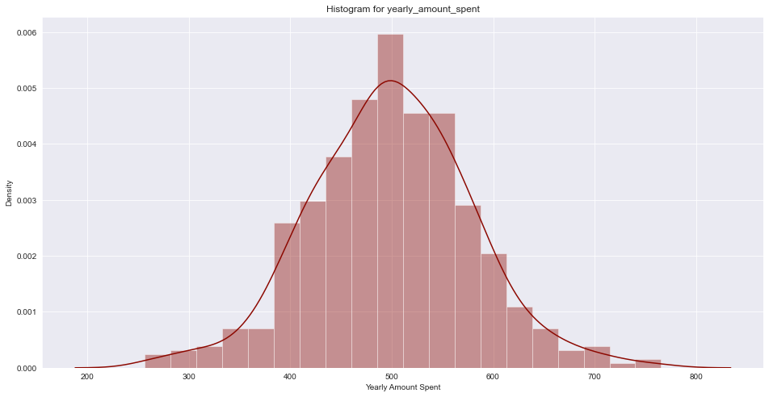

```python
# Setting plot area
f, ax = plt.subplots(figsize=(16, 8))

# plotting the distribution plot
sns.distplot(df['Yearly Amount Spent'], color="r", axlabel='Yearly Amount Spent')
ax.set(title="Histogram for yearly_amount_spent")
plt.show()
```

# Data Visualisation

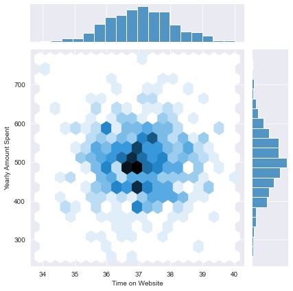

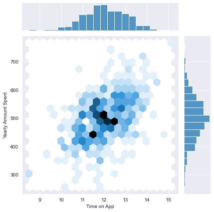

```python
sns.jointplot(data=df, x="Time on Website", y="Yearly Amount Spent", kind="hex")
sns.jointplot(data=df, x="Time on App", y="Yearly Amount Spent", kind="hex")
```

The amount of time spent on the app correlates more to yearly revenues than the amount of time spent on the website

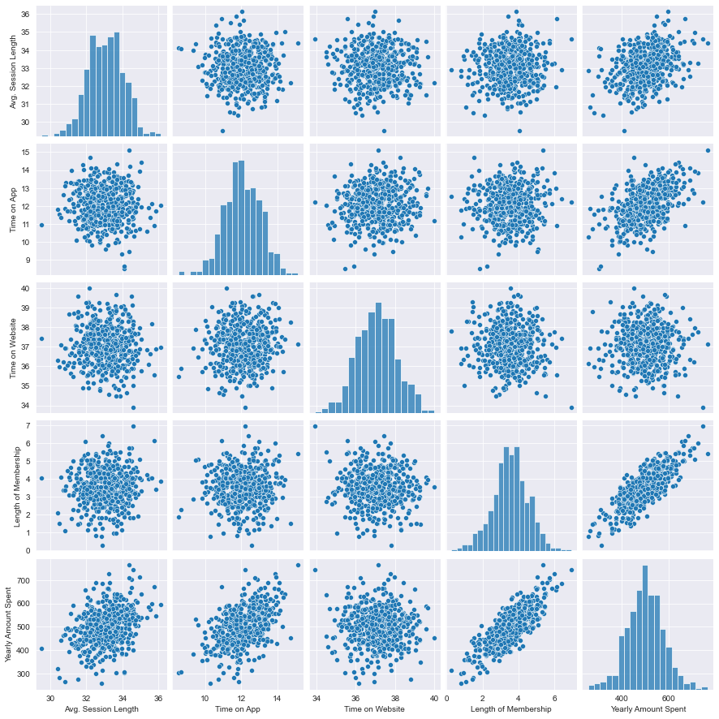

```python
sns.pairplot(df)
```

Based on this plot it seems that the length of membership feature is strongly correlated to the amount that is spent yearly.

# Regression Model

Splitting dataset into training data and testing data

Let's go ahead and split the dataset into training and testing sets. We will use the training set to train our model and use testing set to test our model.

We will set the variable 'x' equal to the numerical features of the customers. These are the features we will use to see how they increase the value of Yearly Amount Spent(i.e the 'y' variable or the sales of the company)

The variable 'y' is the "Yearly Amount Spent" column. We are trying to find out how the other features contribute in increasing the yearly Amount Spent by the customers(i.e the Sales of the company)

```python
X = df[['Avg. Session Length', 'Time on App','Time on Website', 'Length of Membership']]
y = df['Yearly Amount Spent']
```

```python
X_train, X_test, y_train, y_test = train_test_split(X, y, test_size=0.3, random_state=100)
```

```python
model = LinearRegression()
```

```python
model.fit(X_train,y_train)
```

```
LinearRegression()
```

```python
print('Coefficients: \n', model.coef_)
#So we got our Coefficients now
```

```
Coefficients:
 [26.15532441 38.62008494  0.31760347 61.82039406]
```

```python
prediction = model.predict(X_test)
```

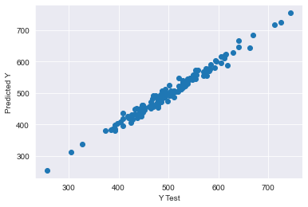

```python
plt.scatter(y_test,prediction)
plt.xlabel('Y Test')
plt.ylabel('Predicted Y')
```

Well the the data points are scatttered in a line which tells us how well our predictions are correlated to the test data points

We will calculate the Mean Absolute Error (MAE), Mean Squared Error (MSE), and the Root Mean Squared Error (RMSE)

```python
print('MAE:', metrics.mean_absolute_error(y_test, prediction))
print('MSE:', metrics.mean_squared_error(y_test, prediction))
print('RMSE:', np.sqrt(metrics.mean_squared_error(y_test, prediction)))
```

```
MAE: 8.511790290965878
MSE: 114.37618082343722
RMSE: 10.694680024359645
```

# Conclusion

Okay so looks like our model is ready. Time to study the features and see how they affect the yearly amount spent by the customers

```python
coeffecients = pd.DataFrame(model.coef_,X.columns)
coeffecients.columns = ['Coeffecient']
coeffecients
```

|  | Coeffecient |
| --- | --- |
| Avg. Session Length | 26.155324 |
| Time on App | 38.620085 |
| Time on Website | 0.317603 |
| Length of Membership | 61.820394 |

Below is what we can interpret from the coefficient of our model.

1. Avg. Session Length increases the Yearly Amount Spent by almost 26 units
2. Time on App increases the Yearly Amount Spent by 38 units
3. Time on Website increases the Yearly Amount Spent by 0.3 units
4. Length of Membership increases the Yearly Amount Spent by 61 units

We can conclude that the time spent on the App is more correlated to the customer's yearly expenditure and it is evident that we should focus more on building the app to draw more business from the customers.

We also noticed that the Lenght of the Membership correlates to yearly amount spend even more! Well it would be a good idea if in future we explore on how we can work on increasing the length of membership to increase customer's yearly spent amount.

Comclusion: Mobile App it is!